# Human Activity Recognition

Arkaitz Etxezarreta

julio 31, 2017

## Overview

One thing that people regularly do is quantify how much of a particular activity they do, but they rarely quantify how well they do it. The goal of this project is to use data from accelerometers on the belt, forearm, arm, and dumbell of 6 participants to predict the manner in which they did the exercise. The actual exercise is the `classe` variable in the training set.

A prediction model has been built using the Random Forest algorithm. The model performance has been measured on the validation dataset and finally it has been used to predict 20 different test cases, all of which turned out to be correct.

## 1. Weight Lifting Exercises Dataset

The first step is to download the training and test data sets and load them appropriately.

More information about this dataset is available here: [`Weight Lifting Exercises (WLE) Dataset`](http://groupware.les.inf.puc-rio.br/har#weight_lifting_exercises) [^1].

```r
# Remove all objects from the global environment
rm(list = ls())

# Download the training and test data for the project
if(!file.exists("./data")) {dir.create("./data")}
if(!file.exists("data/pml-training.csv")) {
    download.file(
        url = "https://d396qusza40orc.cloudfront.net/predmachlearn/pml-training.csv",
        destfile = "./data/pml-training.csv",
        method = "curl")}
if(!file.exists("data/pml-testing.csv")) {
    download.file(
        url = "https://d396qusza40orc.cloudfront.net/predmachlearn/pml-testing.csv",
        destfile = "./data/pml-testing.csv",
        method = "curl")}
dateDownloaded = date()

# Load data
training <- read.csv2("data/pml-training.csv",
                      sep = ",", header = TRUE, na.strings = c("", "NA"))
testing <- read.csv("data/pml-testing.csv",
                    sep = ",", header = TRUE, na.strings = c("", "NA"))
```

## 2. Preprocessing

The data sets have 160 features. I’ve decided to discard those with 75% or more values as NA.

```r
# Load package
selectedCols <- which(colMeans(is.na(training)) < 0.75)
selectedCols <- selectedCols[-c(1:7)]

# Subset the data
training <- training[, selectedCols]
testing <- testing[, selectedCols]
testing$problem_id <- NULL # Remove 'problem_id' from the testing dataset
```

Now I’m going to convert all data but the outcome (`classe`) to numeric variables to make them easier to deal with.

Factor variables mustn’t be transformed straight to numeric variables. The generic function `as.character()` must be applied first. Otherwise the factors will be converted to their numeric storage values instead.

```r
# Function to convert all variables to numeric
toNumeric <- function(data, outcome) {
    as.data.frame(
        lapply(data,
               FUN = function(x) {
                   if (is.factor(x)) as.numeric(as.character(x))
                   else as.numeric(x)}))
}

# Training dataset (it'll be then split into training and validation datasets)
training.labels <- training$classe
training <- toNumeric(training[, -which(names(training) == "classe")])
training$classe <- training.labels

# Testing dataset
testing <- toNumeric(testing)

# Center and scale all values
library(caret)
preProc <- preProcess(training, method = c("center", "scale"),
                      thresh = .95)
training <- predict(preProc, training)
testing <- predict(preProc, testing)
```

In addition, all variables have been centered and scaled.

## 3. Ensemble Modeling

```r
# Split training data into training and validation datasets
set.seed(1492)
trainIndex <- createDataPartition(y = training$classe, p = 0.8, list = FALSE)
training <- training[trainIndex, ]
validation <- training[-trainIndex, ]
```

Next, I will use Random Forest to build a prediction model. Because this algorithm is computationally expensive, I will first load the `doMC` package and use it to allow for parallel execution of the model.

```r
# Register all logical cores to use for parallel execution
library(doMC)
registerDoMC(cores = detectCores())

# Train a Random Forest on the training data set
library(randomForest)
rf.fit <- randomForest(classe ~ ., data = training,
                       method = "rf",
                       ntree = 250)

# Use model to predict on validation data set
rf.val.pred <- predict(rf.fit, validation)

# Predicted result
rf.val.cm <- confusionMatrix(rf.val.pred, validation$classe)
```

The accuracy of the model on the validation dataset is: 1 (this is fairly unusual). Let’s next ckeck out the confusion matrix.

```r
# Confusion Matrix
rf.val.cm$table
```

```
##           Reference
## Prediction   A   B   C   D   E
##          A 906   0   0   0   0
##          B   0 607   0   0   0
##          C   0   0 537   0   0
##          D   0   0   0 512   0
##          E   0   0   0   0 576
```

The OOB (out-of-bag) error rate returned by the model is a good estimate for the out of sample error rate, so before applying the model to the test dataset, let’s plot the OOB error rate along with the different error rates for the 5 types of excercises (A, B, C, D and E).

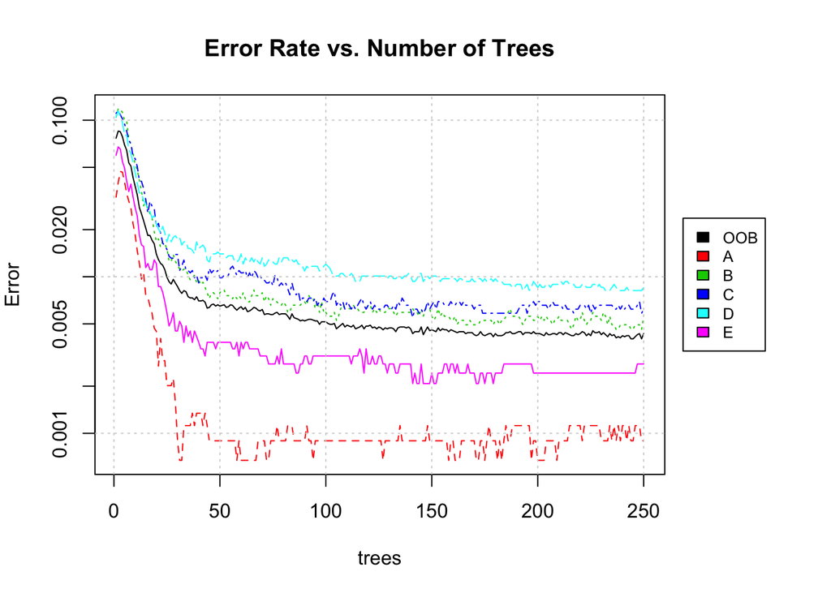

```r
# Plot the error rate as a function of the number of trees
layout(matrix(c(1,2), nrow = 1), width = c(4,1))
par(mar = c(5,4,4,0))
plot(rf.fit, log = "y", main = "Error Rate vs. Number of Trees"); grid()
par(mar=c(5,0,4,2))
plot(c(0,1),type = "n", axes = F, xlab = "", ylab = "")
legend("center", colnames(rf.fit$err.rate), col = 1:6, cex = 0.8, fill = 1:6)
```

## 4. Predicting on the test dataset

Finally, the model trained before is used to predict on the test dataset:

```r
# apply random forest model to test set
predict(rf.fit, testing)
```

```
##  1  2  3  4  5  6  7  8  9 10 11 12 13 14 15 16 17 18 19 20
##  B  A  B  A  A  E  D  B  A  A  B  C  B  A  E  E  A  B  B  B
## Levels: A B C D E
```

All the 20 predictions turned out to be correct according to the last test of the course… Yay! :-)

[^1]: Velloso, E.; Bulling, A.; Gellersen, H.; Ugulino, W.; Fuks, H. Qualitative Activity Recognition of Weight Lifting Exercises. Proceedings of 4th International Conference in Cooperation with SIGCHI (Augmented Human ’13) . Stuttgart, Germany: ACM SIGCHI, 2013.